# Assisted Use in the Confocal Microscopy Facility, FY2018

# Purpose

To find out the proportion of assisted and non-assisted use by HICCC members and non-members during a fiscal year.

# Getting source data

Go to the iLab reporting section and follow the steps below.

Just select the default charts – they won’t be used.

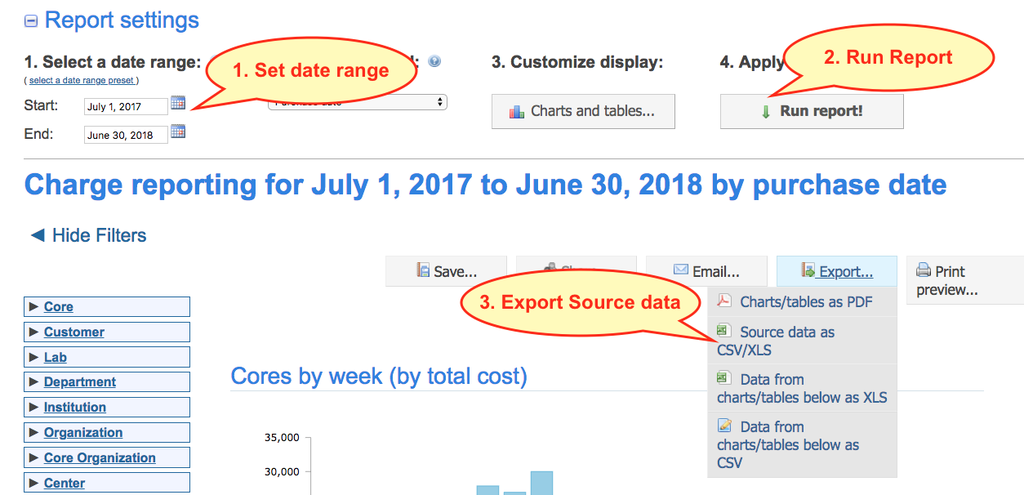

For this period, the output file is called `07012017_06302018_charges_report_source_data.csv`.

Each row in the table represents one reservation or billed service request.

To analyze this file, *add the filename and path to the R code in this notebook*.

```r
library(dplyr)
library(readr)
datapath <- "/Users/confocal/github_theresaswayne/data-analysis/R/usage_data"
datafile <- "07012017_06302018_charges_report_source_data.csv"
usage <- read_csv(file.path(datapath, datafile))
```

# Collecting data by usage type

For each reservation, the level of assistance is recorded in the “Usage Type” column.

The possible values in this column are shown below.

```r
usage$`Usage Type` <- factor(usage$`Usage Type`)
levels(usage$`Usage Type`)
```

```
[1] "1"                         "Assisted Use"              "General Use"
[4] "Independent Off-Hours"     "Independent Off-Hours Use" "Training"
[7] "Unassisted Peak-Hour Use"  "Unassisted use"
```

Note that Usage Type “1” indicates the Image Processing service.

To get all the hours when a staff member was working with, or for, a user, we need to include *Assisted Use*, *Training*, and *1*.

1. First we **filter** the rows that contain these patterns.
2. Then we **select** the column corresponding to the hours of use.
3. Finally we **sum** all the hours.

```r
hrs_assist <- dplyr::filter(usage, grepl("Assisted|Training|1", `Usage Type`)) %>%
                dplyr::select(Quantity) %>%
                sum()
```

Similarly, to get hours when staff was *not* directly assisting, we select for all rows that contain the words *Unassisted* or *Independent*.

```r
hrs_unass <- dplyr::filter(usage, grepl("Unassisted|Independent", `Usage Type`)) %>%
                dplyr::select(Quantity) %>%
                sum()
```

# Summary of assisted hours

The hours and percentage of the total usage are shown below.

```r
hrs_total = hrs_assist + hrs_unass
usage_type <- c("Assisted/Service", "Non-Assisted", "Total")
hours <- c(hrs_assist, hrs_unass, hrs_total)
hrs_summ <- cbind(`Usage Type` = usage_type, Hours = hours) %>%
  as.data.frame(stringsAsFactors = FALSE)
hrs_summ$Hours <- as.numeric(as.character(hrs_summ$Hours)) # force R to see the hours as numeric
hrs_summ <- mutate(hrs_summ,
                Percent = 100 * round((Hours / sum(Hours[-length(Hours)])), 2))
hrs_summ
```

| Usage Type | Hours | Percent |
| --- | --- | --- |
| Assisted/Service | 704.5 | 13 |
| Non-Assisted | 4610.0 | 87 |
| Total | 5314.5 | 100 |

```r
NA
```

# Grouping by HICCC membership

To find out if HICCC members and non-members use different proportions of assisted hours, we can filter by `Price Type` which has the following values:

```r
usage$`Price Type` <- factor(usage$`Price Type`)
levels(usage$`Price Type`)
```

```
[1] "Cancer Center Member" "Dept of Pathology"    "External - Academic"  "Internal - Columbia"
```

We want to break this into 2 categories, `Cancer Center Member` and everything else.

Using the filter-select-sum strategy as above, we can modify our code:

```r
hrs_assist_cc <- dplyr::filter(usage, grepl("Assisted|Training|1", `Usage Type`) & grepl("Cancer Center Member", `Price Type`)) %>%
                dplyr::select(Quantity) %>%
                sum()
hrs_unass_cc <- dplyr::filter(usage, grepl("Unassisted|Independent", `Usage Type`) & grepl("Cancer Center Member", `Price Type`)) %>%
                dplyr::select(Quantity) %>%
                sum()
```

# Final summary

We can get a table of results by calculating some more values and assembling them into a table.

```r
# calculate Total HICCC hours
hrs_total_cc = hrs_assist_cc + hrs_unass_cc
# calculate Non-HICCC hours
hrs_assist_nonCC = hrs_assist - hrs_assist_cc
hrs_unass_nonCC = hrs_unass - hrs_unass_cc
hrs_total_nonCC = hrs_total - hrs_total_cc
# put together each column
hours_cc <- c(hrs_assist_cc, hrs_unass_cc, hrs_total_cc)
hours_nonCC <- c(hrs_assist_nonCC, hrs_unass_nonCC, hrs_total_nonCC)
hours_total <- c(hrs_assist, hrs_unass, hrs_total)
# calculate percentages -- sum all but the last element of the vector (which is the total)
pct_cc = 100 * round((hours_cc / sum(hours_cc[-length(hours_cc)])), 2)
pct_nonCC = 100 * round((hours_nonCC / sum(hours_nonCC[-length(hours_nonCC)])), 2)
pct_total = 100 * round((hours_total / sum(hours_total[-length(hours_total)])), 2)
# bind the columns together into a table
hrs_summ_final <- cbind(`Usage Type` = usage_type,
                        `HICCC` = hours_cc,
                        `% of HICCC usage` = pct_cc,
                        `Non-HICCC` = hours_nonCC,
                        `% of Non-HICCC usage` = pct_nonCC,
                        `Total` = hours_total,
                        `% of Total` = pct_total) %>%
  as.data.frame(stringsAsFactors = FALSE)
```

```r
# show the table
hrs_summ_final
```

| Usage Type | HICCC | % of HICCC usage | Non-HICCC | % of Non-HICCC usage | Total | % of Total |
| --- | --- | --- | --- | --- | --- | --- |
| Assisted/Service | 330.5 | 11 | 374 | 16 | 704.5 | 13 |
| Non-Assisted | 2626.5 | 89 | 1983.5 | 84 | 4610 | 87 |
| Total | 2957 | 100 | 2357.5 | 100 | 5314.5 | 100 |